# Project - Group 18

**Members:**

- Andreas Chrysostomou - 5957273
- Harpeet Singh - 4870654
- Lise van Dijk - 4850580
- Ralf Hardy - 5348684
- Sara Jacobs - 4837193

**Github:** https://github.com/HHappy7/TIL6010-GroupProject.git

## Introduction and Research Objective:

The COVID-19 pandemic brought about profound changes in our daily lives. One significant impact that the pandemic had was on transportation. As the world grappled with lockdowns and quarantines, people moved less, and travel patterns shifted. This research aims to investigate the effects of COVID-19 on transportation emission levels in Europe, by answering the following **research question:**

*"What was the effect of COVID-19 on transport emission levels in Europe, comparing the pre-pandemic period with the pandemic period?"*

To comprehensively address this question, we have formulated the following **sub-questions:**

1. *Among CO2, PM10, PM2.5, and NOx emissions, which substance experienced the most substantial decline during the pandemic?*
2. *Which European countries exhibited the most significant and least significant differences in transport-related emissions due to the pandemic?*
3. *Are variations in the effect of COVID-19 on transportation emissions related to a country's GDP?*

To achieve this, we will employ a methodical approach. We will analyze datasets containing annual transportation emission levels for European countries, focusing on the years 2019 and 2020. By computing the differences in emissions during these two pivotal years, we aim to discern the specific influence of the pandemic.

## Import Libraries

```python
import pandas as pd
from pathlib import Path
import numpy as np
import math
import scipy
from scipy.signal import find_peaks
import plotly.graph_objects as go
import plotly.express as px
from plotly.subplots import make_subplots
import datetime
import seaborn as sns
import matplotlib.pyplot as plt
%matplotlib inline
import geopandas as gpd
from urllib.request import urlopen
import json
```

## Sub-question 1

### Part I - Data Import & Part II - Data Processing

Emissions of various pollutants decreased significantly in the European Union (EU) countries during the COVID-19 pandemic. CO2 emissions, primarily associated with the use of fossil fuels, noticeably dropped due to lockdown measures and reduced transport activity. Similarly, pandemic restrictions led to a significant decrease in PM10, PM2.5 and NOx levels in the air. Subquestion 1 endeavors to identify which of the specified pollutants (CO2, PM10, PM2.5) or NOx emissions demonstrated the most notable decrease during the pandemic in EU countries.\ \ All data regarding emissions were found through European Statistical Office (Eurostat). These datasets needed to be filtered because of additional countries and additional years. First the total value of all differrent emissions for 2019 and 2020 for all European Union Countries. Countries that are not part of European Union were filtered out of the processed data. The specific on how the the data is imported, filtered and processed can be found in the 'Filter subquestion 1' file.

### Part III - Data Visualization

Gathered and processed data were clearly visualised using a bar plot in order to highlight the emissions difference for the different emission and pollutants types examined pre and during COVID-19 pandemic.

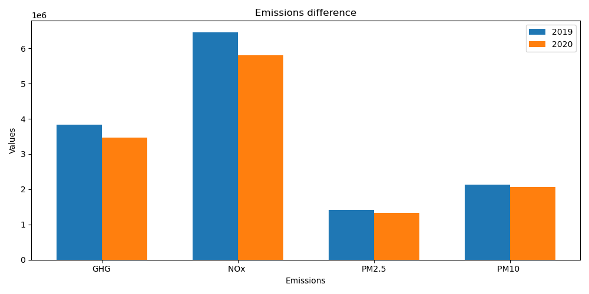

```python
from IPython.display import Image

Image('Emissions_Difference.png')
```

### Conclusion sub-question 1

Overall, the bar chart illustrates a downward trend regarding the total emissions of GHG, NOx PM2.5 and PM10 between the two examined years, 2019 and 2020, pre and during COVID-19 era. The most significant change was observed in the value of total NOx emissions throughout the examined years. A mild reduction was observed in the emissions of PM2.5 and PM10 from 2019 to 2020 among the European Union countries. Finally, GHG emissions also decreased during the examined pre and during COVID-19 years.

## Sub-question 2

### Part I - Data Import & Part II - Data Processing

This sub-question looks at the Greenhouse Gases for each countries in the years 2019 and 2020. The previous sub-question discussed the differences by emission type. This sub-question looks at the differences by country for the GreenHouse gases. This means that we look at the GHG of a country in 2019 and compare this to the GHG of this same country in 2020. \ \ All data regarding GHG is found through European Statistical Office (Eurostat). These dataset needed to be filtered because of additional countries and additional years, this is also done in the previous subquestion. The specific on how the the data is imported, filtered and processed can be found in the 'Filter subquestion 2' file.

### Part III - Data Visualization

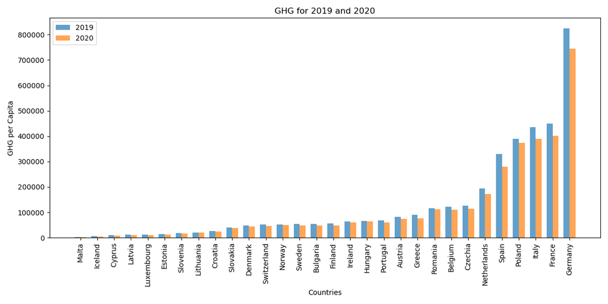

```python
from IPython.display import Image

Image('Emmissions19v20.png')
```

As shown in the figure above (*GHG for 2019 and 2020*) there is a wide variety of GreenHouse Gas emissions within Europe. Obviusly, smaller countries such as Cyprus or Malta have much lower levels of GHG emissions. It can be seen nonetheless that the emissions of all countries decreased comparing the pandemic year 2020 with the pre-pandemic year 2019. \ \ There are several noteworthy observation to be mentioned. Firstly, the greenhouse gasses of Germany are extremely high compared to other large European countries. Besides that Romania has relatively low emission levels, when taking into account that their population is bigger than the Netherlands, Czechia and Belgium.

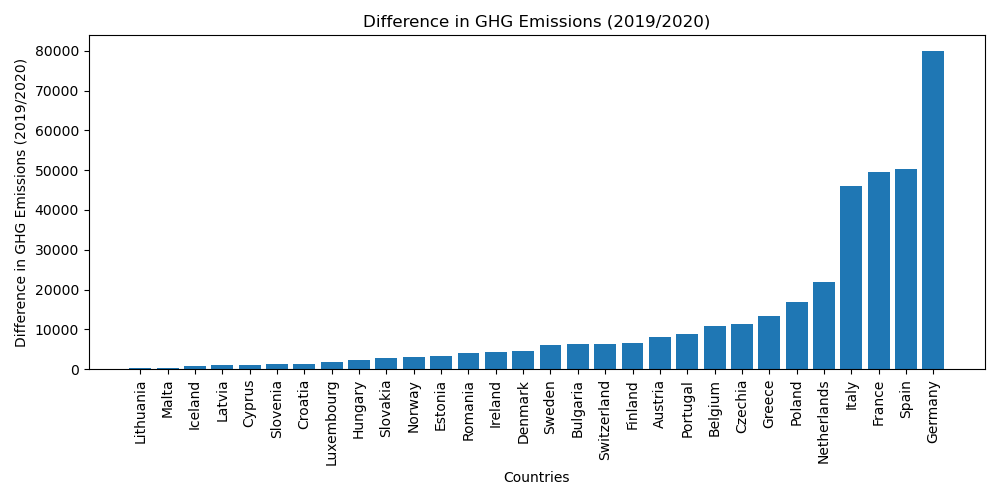

```python
from IPython.display import Image

Image('GHGdifference.png')
```

The figure shown above (*Difference in GHG Emissions 2019/2020*) visualizes for each country the difference in their greenhouse gas emissions between the pandemic year 2020 and the pre-pandemic year 2019. \ \ It can be observed in the figure, that defining the variation in greenhouse gas emissions for each European country between the pre-pandemic and pandemic year, can be attributed to the concept of relative change. Countries with higher absolute emission values naturally have a greater margin for reduction, and thus, their emissions may register a more noticeable decline. This is due to the fact that a proportionally smaller reduction in absolute emissions for these countries can still translate into a substantial decrease in terms of actual volume. In contrast, countries with initially lower absolute emission values might experience a significant percentage decrease but contribute less to the overall reduction in greenhouse gas emissions. Therefore, the magnitude of decline is influenced by the baseline emissions of each country.\ \ The results also show that Spain has a more noticable decline in emissions in comparison to the other so-called 'big polluters'. It can be seen that Spain has a greater decrease due to the Covid-19 pandemic than France, Italy and Poland. This is quite noteworthy because these three countries have higher absolute greenhouse gas emissions.

### Sub-question 3:

*Are variations in the effect of COVID-19 on transportation emissions related to a country's GDP?*

#### Part I - Data Import & Part II - Data Processing

For this sub-question we looked into the GDP (per capita) per country, GDP stands for Gross Domestic Product and per capita means the average per inhabitant. GDP data per capita is used to see the GDP of the countries more 'fairly'. In sub-question 1 and 2 are the differences calculated for the emissions in the year 2019 and 2020. In this subquestion will be calculated if the GDP per country changed in these two periods. When this is calculated then we can see if there is a relationship between the changes in pollution and the changes in GDP. \ \ So first, we looked at the GDP of the countries for 2019 versus 2020. Then we took the difference for all those countries between those two years, to see the effect of Covid on the GDP of a country. After this we looked at the relation between the GDP in 2020 and the differences in GHG (20-19) per country. This was done by visualizing it in a scatter plot.

All data regarding GHD is found through European Statistical Office (Eurostat). These dataset needed to be filtered because of additional countries and additional years, this is also done in the previous subquestion. The details on how the the data is imported, filtered and processed can be found in the 'Filter subquestion 3' file.

### Part III - Data Visualization

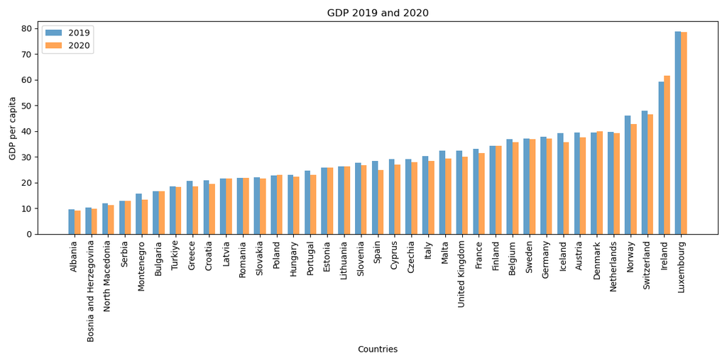

```python
from IPython.display import Image

Image('GDP19v20.png')
```

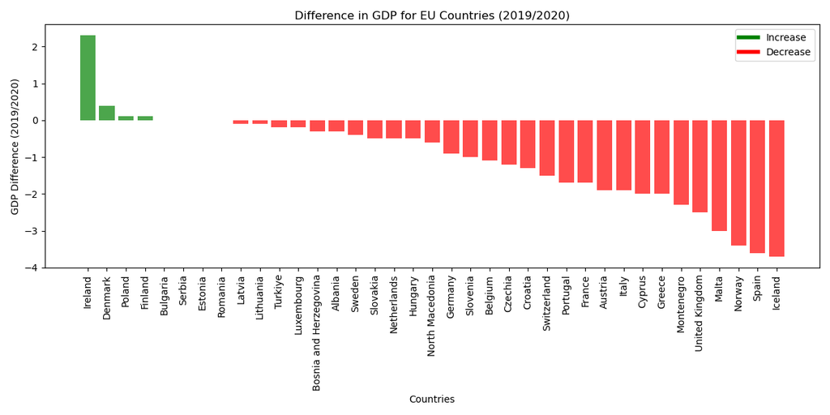

```python
from IPython.display import Image

Image('GDPdifference.png')
```

To see if there is an effect between GDP per country and difference in GHG emission-difference due to transport between 2019 and 2020, a scatterplot is made. On the x-axis the GDP is shown of the EU countries in 2020 and on the y-axis we have shown the difference in GHG between 2019 and 2020, which is also shown per country in a barplot above. When you put those two together, conclusions can be made about the influence of GDP per country and the grip they have on GHG emissions.

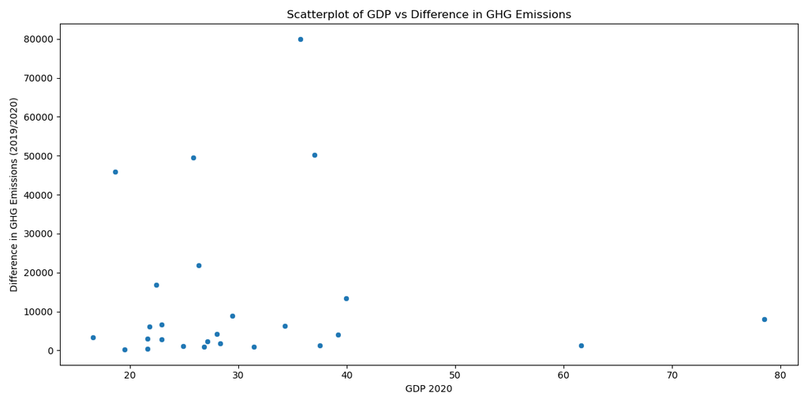

```python
from IPython.display import Image

Image('ScatterGDPGHG.png')
```

### Conclusion sub-question 3

It can be concluded that there is not an exact relation between the effect of Covid-19 on transportation emissions and the GDP of a country. The results of the scatterplot give a wide variety of combinations in GDP and differences in GHG emissions. Futhermore, it can be concluded that Luxembourg and Ireland, as the countries with the highest GDP's, do not experience major changes in GHG emissions due to Covid-19. \ \ So, the research can not determine a clear relation between these two concepts. Further research is needed to gain more insight and knowledge in this field.

## Conclusion research question

*What was the effect of COVID-19 on transport emission levels in Europe, comparing the pre-pandemic period with the pandemic period?*\ \ This research question can be answerd by answering the sub-questions. This is why the conclusions of the different sub-questions also contribute to the conclusion of the research question.

By considering the results of the research, it can be conclused that there was a significant decline of transport emission levels in Europe due to the Covid-19 pandemic. To begin with one of the most important emissions the greenhouse gasses, these had a quite significant decrease. But, the most significant decline was in the total NOx emissions in Europe. In addition to that also the PM2.5 and PM10 emissions were reduced within Europe. \ \ Secondly, Germany and Spain, both one of the biggest European countries, are the countries with the most significant difference in greenhouse gas emissions for the pre-pandemic year 2019 and pandemic year 2020. And the two countries Lithuania and Malta are the ones with the lowest differences in that matter. But, these results are heavily based on the population of a country because of the linear relationship with a country's emissions and their population. Thus, the results can be more precise and usefull if the relative change is presented. Further research is needed to determine these results. \ \ Furthermore, it can be concluded from the research that the variations in the effect of COVID-19 on transportation emissions are not related to a country's GDP (per capita). A more in-depth follow-up study could delve more into the connection of these concepts, and is needed to prove a possible relation between the differences in GHG emissions and the GDP per capita of a country.

## Contribution Statement

**Andreas Chrysostomou:**

- Finding the correct datasets for the research.
- Filtering the data for sub-question 1.
- Creating the vizualisations for sub-question 1.
- Writing of explanations regarding sub-question 1.

**Harpeet Singh:**

- Setting up the Github Repository.
- Finding the correct datasets for the research.
- Filtering the data for sub-question 1.
- Creating the vizualisations for sub-question 1.
- Writing of explanations regarding sub-question 1.

**Lise van Dijk:**

- Finding the correct datasets for the research.
- Filtering the data for sub-question 2 and 3.
- Creating the vizualisations for answering sub-question 2 and 3.
- Writing of explanations regarding sub-question 2 and 3.
- Creating and designing the final report lay-out.

**Ralf Hardy:**

- Finding the correct datasets for the research.
- Filtering the data for sub-question 2 and 3.
- Creating the vizualisations for sub-question 2 and 3.
- Writing of explanations regarding sub-question 2 and 3.
- Elaborating and writing conclusions for sub-question 2 and 3.
- Writing the conclusion of the main research question.
- Creating and designing the final report lay-out.

**Sara Jacobs:**

- Finding the correct datasets for the research.
- Creating the vizualisations for sub-question 2 and 3.
- Creating structure in the files and Github
- Elaborating and writing conclusions for sub-question 2 and 3.

## Data Sources

- NOx emissions data from the Eurostat database: https://ec.europa.eu/eurostat/databrowser/view/env_air_emis__custom_7911608/default/table
- PM2.5 emissions data from the Eurostat database: https://ec.europa.eu/eurostat/databrowser/view/env_air_emis__custom_7911608/default/table
- PM10 emissions data from the Eurostat database: https://ec.europa.eu/eurostat/databrowser/view/env_air_emis__custom_7911608/default/table
- GHG emissions data from the Eurostat database: https://ec.europa.eu/eurostat/web/products-datasets/-/sdg_13_10
- GDP per capita data from the Eurostat database: https://ec.europa.eu/eurostat/web/products-datasets/-/sdg_08_10